# Supervised Learning - Project 2

Supervised Learning Project

Data Description: The file Bank.xls contains data on 5000 customers. The data include customer demographic information (age, income, etc.), the customer's relationship with the bank (mortgage, securities account, etc.), and the customer response to the last personal loan campaign (Personal Loan). Among these 5000 customers, only 480 (= 9.6%) accepted the personal loan that was offered to them in the earlier campaign.

Domain:Banking

Context:This case is about a bank (Thera Bank) whose management wants to explore ways of converting its liability customers to personal loan customers (while retaining them as depositors). A campaign that the bank ran last year for liability customers showed a healthy conversion rate of over 9% success. This has encouraged the retail marketing department to devise campaigns with better target marketing to increase the success ratio with minimal budget.

Attribute Information:

1. ID: Customer ID
2. Age: Customer's age in completed years
3. Experience: #years of professional experience
4. Income: Annual income of the customer (in thousands of dollars)
5. ZIP Code: Home Address ZIP code.
6. Family: Family size of the customer
7. CCAvg: Avg. spending on credit cards per month (in thousands of dollars)
8. Education: Education Level.
   1. Undergrad
   2. Graduate
   3. Advanced/Professional
9. Mortgage: Value of house mortgage if any. (in thousands of dollars)
10. Personal Loan : Did this customer accept the personal loan offered in the last campaign?
11. Securities Account : Does the customer have a securities account with the bank?
12. CD Account : Does the customer have a certificate of deposit (CD) account with the bank?
13. Online : Does the customer use internet banking facilities?
14. Credit card : Does the customer use a credit card issued by UniversalBank?

The classification goal is to predict the likelihood of a liability customer buying personal loans.

```python
import pandas as pd
import numpy as np
import matplotlib.pyplot as plt
from matplotlib.pyplot import figure
import seaborn as sns
import warnings

from sklearn.metrics import classification_report, confusion_matrix, roc_auc_score, roc_curve, accuracy_score

warnings.filterwarnings("ignore")
```

```python
#reading the data

loan = pd.read_csv("Bank_Personal_Loan_Modelling.csv")
```

```python
loan.head() #checking the head
```

|  | ID | Age | Experience | Income | ZIP Code | Family | CCAvg | Education | Mortgage | Personal Loan | Securities Account | CD Account | Online | CreditCard |
| --- | --- | --- | --- | --- | --- | --- | --- | --- | --- | --- | --- | --- | --- | --- |
| 0 | 1 | 25 | 1 | 49 | 91107 | 4 | 1.6 | 1 | 0 | 0 | 1 | 0 | 0 | 0 |
| 1 | 2 | 45 | 19 | 34 | 90089 | 3 | 1.5 | 1 | 0 | 0 | 1 | 0 | 0 | 0 |
| 2 | 3 | 39 | 15 | 11 | 94720 | 1 | 1.0 | 1 | 0 | 0 | 0 | 0 | 0 | 0 |
| 3 | 4 | 35 | 9 | 100 | 94112 | 1 | 2.7 | 2 | 0 | 0 | 0 | 0 | 0 | 0 |
| 4 | 5 | 35 | 8 | 45 | 91330 | 4 | 1.0 | 2 | 0 | 0 | 0 | 0 | 0 | 1 |

```python
loan.shape # getting the shape
```

```
(5000, 14)
```

```python
loan.columns #checking the columns
```

```
Index(['ID', 'Age', 'Experience', 'Income', 'ZIP Code', 'Family', 'CCAvg',
       'Education', 'Mortgage', 'Personal Loan', 'Securities Account',
       'CD Account', 'Online', 'CreditCard'],
      dtype='object')
```

```python
loan.info() #info about the data
```

```
<class 'pandas.core.frame.DataFrame'>
RangeIndex: 5000 entries, 0 to 4999
Data columns (total 14 columns):
ID                    5000 non-null int64
Age                   5000 non-null int64
Experience            5000 non-null int64
Income                5000 non-null int64
ZIP Code              5000 non-null int64
Family                5000 non-null int64
CCAvg                 5000 non-null float64
Education             5000 non-null int64
Mortgage              5000 non-null int64
Personal Loan         5000 non-null int64
Securities Account    5000 non-null int64
CD Account            5000 non-null int64
Online                5000 non-null int64
CreditCard            5000 non-null int64
dtypes: float64(1), int64(13)
memory usage: 547.0 KB
```

The data has 14 columns, 5000 Rows, 13 integers types and one float type variables. All of them are non-null

```python
loan.isna().apply(pd.value_counts)   #null value check
```

|  | ID | Age | Experience | Income | ZIP Code | Family | CCAvg | Education | Mortgage | Personal Loan | Securities Account | CD Account | Online | CreditCard |
| --- | --- | --- | --- | --- | --- | --- | --- | --- | --- | --- | --- | --- | --- | --- |
| False | 5000 | 5000 | 5000 | 5000 | 5000 | 5000 | 5000 | 5000 | 5000 | 5000 | 5000 | 5000 | 5000 | 5000 |

There are no null values as al the columns have 5000 entries

```python
loan.describe().T # 5 point summary of the continuous attributes
```

|  | count | mean | std | min | 25% | 50% | 75% | max |
| --- | --- | --- | --- | --- | --- | --- | --- | --- |
| ID | 5000.0 | 2500.500000 | 1443.520003 | 1.0 | 1250.75 | 2500.5 | 3750.25 | 5000.0 |
| Age | 5000.0 | 45.338400 | 11.463166 | 23.0 | 35.00 | 45.0 | 55.00 | 67.0 |
| Experience | 5000.0 | 20.104600 | 11.467954 | -3.0 | 10.00 | 20.0 | 30.00 | 43.0 |
| Income | 5000.0 | 73.774200 | 46.033729 | 8.0 | 39.00 | 64.0 | 98.00 | 224.0 |
| ZIP Code | 5000.0 | 93152.503000 | 2121.852197 | 9307.0 | 91911.00 | 93437.0 | 94608.00 | 96651.0 |
| Family | 5000.0 | 2.396400 | 1.147663 | 1.0 | 1.00 | 2.0 | 3.00 | 4.0 |
| CCAvg | 5000.0 | 1.937938 | 1.747659 | 0.0 | 0.70 | 1.5 | 2.50 | 10.0 |
| Education | 5000.0 | 1.881000 | 0.839869 | 1.0 | 1.00 | 2.0 | 3.00 | 3.0 |
| Mortgage | 5000.0 | 56.498800 | 101.713802 | 0.0 | 0.00 | 0.0 | 101.00 | 635.0 |
| Personal Loan | 5000.0 | 0.096000 | 0.294621 | 0.0 | 0.00 | 0.0 | 0.00 | 1.0 |
| Securities Account | 5000.0 | 0.104400 | 0.305809 | 0.0 | 0.00 | 0.0 | 0.00 | 1.0 |
| CD Account | 5000.0 | 0.060400 | 0.238250 | 0.0 | 0.00 | 0.0 | 0.00 | 1.0 |
| Online | 5000.0 | 0.596800 | 0.490589 | 0.0 | 0.00 | 1.0 | 1.00 | 1.0 |
| CreditCard | 5000.0 | 0.294000 | 0.455637 | 0.0 | 0.00 | 0.0 | 1.00 | 1.0 |

#### Observations

1. The distribution of Age covers the range of an individual earning and hence taking a personal loan
2. There is a minimum experience of -3 which doesnt make sense as experience can be 0 or greater
3. Age, Experience, Income, CCAvg, Mortgage are continuous variables
4. Family and Education has several levels of data
5. Personal Loan, Securities Account, CD Account, Online, Credit Card are binary variables

```python
# imputing the negative values of Experience column

Exp_mean = loan.Experience.mean()
loan['Experience'].iloc[np.where(loan['Experience'] < 0)] = Exp_mean
```

```python
#checking the data again
loan.describe().T # 5 point summary of the continuous attributes
```

|  | count | mean | std | min | 25% | 50% | 75% | max |
| --- | --- | --- | --- | --- | --- | --- | --- | --- |
| ID | 5000.0 | 2500.500000 | 1443.520003 | 1.0 | 1250.75 | 2500.5000 | 3750.25 | 5000.0 |
| Age | 5000.0 | 45.338400 | 11.463166 | 23.0 | 35.00 | 45.0000 | 55.00 | 67.0 |
| Experience | 5000.0 | 20.328688 | 11.253009 | 0.0 | 11.00 | 20.1046 | 30.00 | 43.0 |
| Income | 5000.0 | 73.774200 | 46.033729 | 8.0 | 39.00 | 64.0000 | 98.00 | 224.0 |
| ZIP Code | 5000.0 | 93152.503000 | 2121.852197 | 9307.0 | 91911.00 | 93437.0000 | 94608.00 | 96651.0 |
| Family | 5000.0 | 2.396400 | 1.147663 | 1.0 | 1.00 | 2.0000 | 3.00 | 4.0 |
| CCAvg | 5000.0 | 1.937938 | 1.747659 | 0.0 | 0.70 | 1.5000 | 2.50 | 10.0 |
| Education | 5000.0 | 1.881000 | 0.839869 | 1.0 | 1.00 | 2.0000 | 3.00 | 3.0 |
| Mortgage | 5000.0 | 56.498800 | 101.713802 | 0.0 | 0.00 | 0.0000 | 101.00 | 635.0 |
| Personal Loan | 5000.0 | 0.096000 | 0.294621 | 0.0 | 0.00 | 0.0000 | 0.00 | 1.0 |
| Securities Account | 5000.0 | 0.104400 | 0.305809 | 0.0 | 0.00 | 0.0000 | 0.00 | 1.0 |
| CD Account | 5000.0 | 0.060400 | 0.238250 | 0.0 | 0.00 | 0.0000 | 0.00 | 1.0 |
| Online | 5000.0 | 0.596800 | 0.490589 | 0.0 | 0.00 | 1.0000 | 1.00 | 1.0 |
| CreditCard | 5000.0 | 0.294000 | 0.455637 | 0.0 | 0.00 | 0.0000 | 1.00 | 1.0 |

#### Observations

1. It can be observed, the negative values of Experience are relpaced with the mean of Experience and the minimum value is now 0

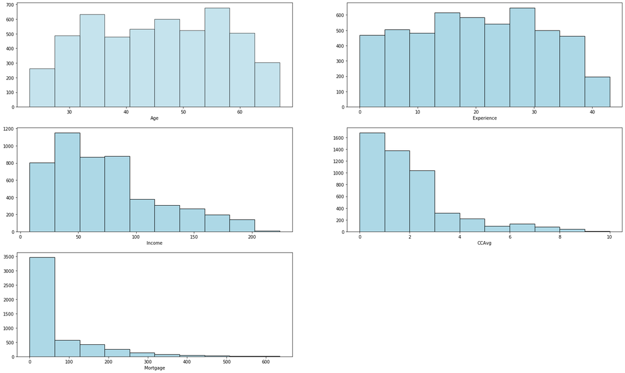

```python
#Plots to see the distribution of the continuous features individually

plt.figure(figsize= (25,15))

plt.subplot(3,2,1)
plt.hist(loan.Age, color='lightblue', edgecolor = 'black', alpha = 0.7)
plt.xlabel('Age')

plt.subplot(3,2,2)
plt.hist(loan.Experience, color='lightblue', edgecolor = 'black')
plt.xlabel('Experience')

plt.subplot(3,2,3)
plt.hist(loan.Income, color='lightblue', edgecolor = 'black')
plt.xlabel('Income')

plt.subplot(3,2,4)
plt.hist(loan.CCAvg, color='lightblue', edgecolor = 'black')
plt.xlabel('CCAvg')

plt.subplot(3,2,5)
plt.hist(loan.Mortgage, color='lightblue', edgecolor = 'black')
plt.xlabel('Mortgage')


plt.show()
```

#### Observations

1. Age and Experience are pretty much uniformly distributed
2. There are significant number of individuals with income less than $100k$ Dollars compared to more than $100k$ Dollars
3. CCavg and Mortgage have skewed distributions

```python
# Measure the skeweness of the required columns

import statsmodels.api as sm
import scipy.stats as stats

Skewness = pd.DataFrame({'Skewness' : [stats.skew(loan.Age),stats.skew(loan.Experience),stats.skew(loan.Income),
                                       stats.skew(loan.CCAvg), stats.skew(loan.Mortgage)]},
                        index=['Age','Experience','Income','CCAvg','Mortgage'])
Skewness
```

|  | Skewness |
| --- | --- |
| Age | -0.029332 |
| Experience | -0.014385 |
| Income | 0.841086 |
| CCAvg | 1.597964 |
| Mortgage | 2.103371 |

#### Observations

1. As seen earlier from the distributions, CCAvg and Mortgage are highly skewed
2. Income is marginally skewed
3. Age and Experience have a fairly uniform distribution

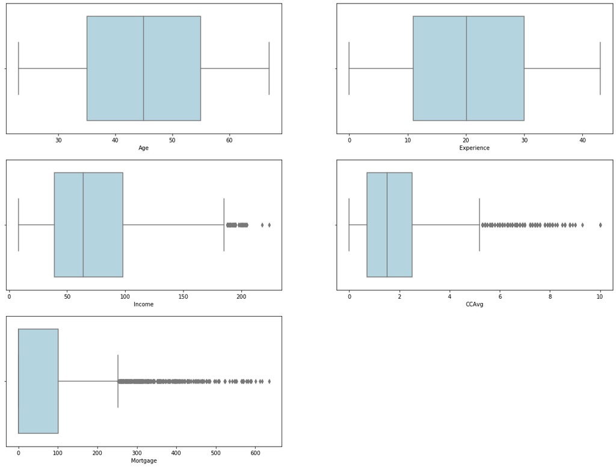

```python
# checking for outliers in the data

plt.figure(figsize= (20,15))

plt.subplot(3,2,1)
sns.boxplot(x= loan.Age, color='lightblue')

plt.subplot(3,2,2)
sns.boxplot(x= loan.Experience, color='lightblue')

plt.subplot(3,2,3)
sns.boxplot(x= loan.Income, color='lightblue')

plt.subplot(3,2,4)
sns.boxplot(x= loan.CCAvg, color='lightblue')

plt.subplot(3,2,5)
sns.boxplot(x= loan.Mortgage, color='lightblue')

plt.show()
```

#### Observations

1. Age and Experience have no outliers
2. Income has a few outliers
3. Both CCAvg and Mortgage have a lot of outliers

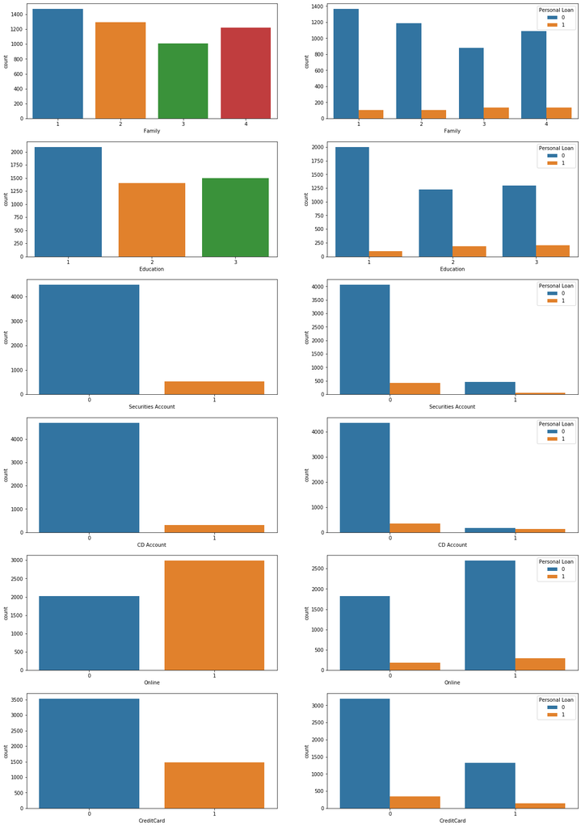

```python
# checking for data distribution of not continuous variables

plt.figure(figsize=(20,30))

#family
plt.subplot(6,2,1)
sns.countplot(x='Family', data = loan)

plt.subplot(6,2,2)
sns.countplot(x='Family', data = loan, hue = 'Personal Loan')

#education
plt.subplot(6,2,3)
sns.countplot(x='Education', data = loan)

plt.subplot(6,2,4)
sns.countplot(x='Education', data = loan, hue = 'Personal Loan')

#Securities Account
plt.subplot(6,2,5)
sns.countplot(x='Securities Account', data = loan)

plt.subplot(6,2,6)
sns.countplot(x='Securities Account', data = loan, hue = 'Personal Loan')

#CD account
plt.subplot(6,2,7)
sns.countplot(x='CD Account', data = loan)

plt.subplot(6,2,8)
sns.countplot(x='CD Account', data = loan, hue = 'Personal Loan')

#Online
plt.subplot(6,2,9)
sns.countplot(x='Online', data = loan)

plt.subplot(6,2,10)
sns.countplot(x='Online', data = loan, hue = 'Personal Loan')

#Credit Card
plt.subplot(6,2,11)
sns.countplot(x='CreditCard', data = loan)

plt.subplot(6,2,12)
sns.countplot(x='CreditCard', data = loan, hue = 'Personal Loan')

plt.show()
```

```python
#getting a count of individuals for Personal Loan
loan['Personal Loan'].value_counts()
print((loan['Personal Loan'].value_counts()/len(loan.index))*100)
```

```
0    90.4
1     9.6
Name: Personal Loan, dtype: float64
```

#### Observations

1. 9.6% of the sample have taken a personal loan
2. 90.4% of the sample have not taken a personal loan

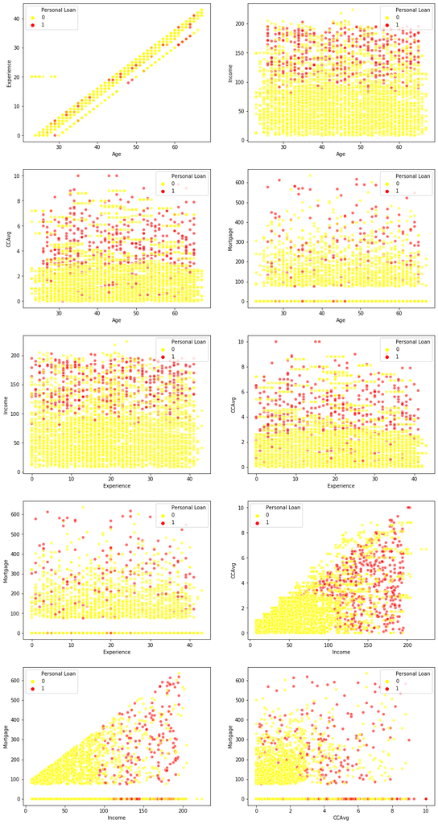

```python
#Scatter plot to look for visual evidence of dependency between attributes age and Experience for Personal Loan

plt.figure(figsize=(15,30))
plt.subplot(5,2,1)
sns.scatterplot(loan.Age, loan.Experience,hue=loan['Personal Loan'],palette= ['yellow','red'] ,alpha=0.6)

plt.subplot(5,2,2)
sns.scatterplot(loan.Age, loan.Income,hue=loan['Personal Loan'],palette= ['yellow','red'] ,alpha=0.6)

plt.subplot(5,2,3)
sns.scatterplot(loan.Age, loan.CCAvg,hue=loan['Personal Loan'],palette= ['yellow','red'] ,alpha=0.6)

plt.subplot(5,2,4)
sns.scatterplot(loan.Age, loan.Mortgage,hue=loan['Personal Loan'],palette= ['yellow','red'] ,alpha=0.6)

plt.subplot(5,2,5)
sns.scatterplot(loan.Experience, loan.Income,hue=loan['Personal Loan'],palette= ['yellow','red'] ,alpha=0.6)

plt.subplot(5,2,6)
sns.scatterplot(loan.Experience, loan.CCAvg,hue=loan['Personal Loan'],palette= ['yellow','red'] ,alpha=0.6)

plt.subplot(5,2,7)
sns.scatterplot(loan.Experience, loan.Mortgage,hue=loan['Personal Loan'],palette= ['yellow','red'] ,alpha=0.6)

plt.subplot(5,2,8)
sns.scatterplot(loan.Income, loan.CCAvg,hue=loan['Personal Loan'],palette= ['yellow','red'] ,alpha=0.6)

plt.subplot(5,2,9)
sns.scatterplot(loan.Income, loan.Mortgage,hue=loan['Personal Loan'],palette= ['yellow','red'] ,alpha=0.6)

plt.subplot(5,2,10)
sns.scatterplot(loan.CCAvg, loan.Mortgage,hue=loan['Personal Loan'],palette= ['yellow','red'] ,alpha=0.6)

plt.show()
```

#### Observations

1. For Age there is a direct correlation with Experience and not really with Income, CCAvg, Mortgage and does not have any trend for an individual taking a personal loan because of Age
2. For Experience other than Age there doesnt seem to be a relationship with Income, CCAvg, Mortgage and does not have any trend for an individual taking a personal loan because of Experience
3. For Income there is a direct correlation with CCAvg and Mortgage and there seems to be a trend of individuals with higher income tend to take personal loans more than the ones with Lower Income
4. Many individuals seem to have lower Mortgage for a lower CCAvg however this is not an established trend as there are other individuals with a higher mortgage and low CCAvg too and this does not establish any trend with Personal Loan

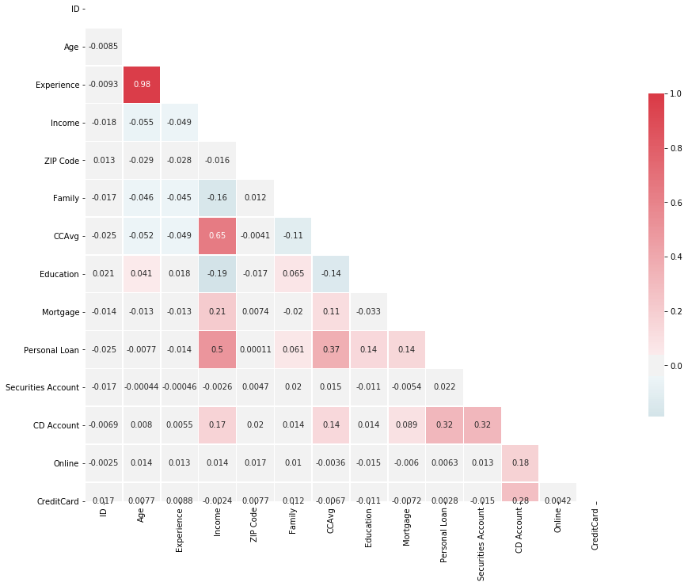

```python
# Correlation matrix for all variables
corr = loan.corr()

mask = np.zeros_like(corr, dtype = np.bool)
mask[np.triu_indices_from(mask)] = True

f, ax = plt.subplots(figsize = (15, 15))

cmap = sns.diverging_palette(220, 10, as_cmap = True)

sns.heatmap(corr, mask = mask, cmap = cmap, vmax = 1, center = 0, square = True,
            linewidths = .5, cbar_kws = {"shrink": .5}, annot = True)
```

#### Observations

1. From the correlation matrix, it is clearly established ID, ZIP Code, Age & Experience have a very minimal influence on Personal Loan
2. Age and Experience are highly correlated
3. Eliminating Experience and considering Age for building the model as there is some small correlation between Age and Education, and Education and Family further

```python
# preparing data
# eliminating columns of ID, ZIP Code and Experience as they dont influence the predictor variable

from sklearn.model_selection import train_test_split

X = loan.drop(columns = ['ID', 'ZIP Code', 'Experience', 'Personal Loan'])     # Predictor feature columns
Y = loan['Personal Loan']   # Predicted class (1=True, 0=False)
```

```python
#preparing the training and testing data set

x_train, x_test, y_train, y_test = train_test_split(X, Y, test_size=0.3, random_state=25)

#check the data split

print("{0:0.2f}% data is in training set".format((len(x_train)/len(loan.index)) * 100))
print("{0:0.2f}% data is in test set".format((len(x_test)/len(loan.index)) * 100))
```

```
70.00% data is in training set
30.00% data is in test set
```

```python
#distribution of predictor class in the train and test dataset in percentages

print((y_train.value_counts()/len(y_train))*100)
print((y_test.value_counts()/len(y_test))*100)
```

```
0    89.942857
1    10.057143
Name: Personal Loan, dtype: float64
0    91.466667
1     8.533333
Name: Personal Loan, dtype: float64
```

#### Observations

The distribution of Personal Loan in train and test seems to be almost same as the loan data set

#### The next step is to fit various models and check for the best performing one

1. Logistic Regression
2. Naive Bayes
3. KNN

```python
# Logistic Regression
from sklearn import metrics

from sklearn.linear_model import LogisticRegression

# Fit the model on train
lr = LogisticRegression(C=1e5)
lr.fit(x_train, y_train)

from sklearn import metrics

lr_train_predict = lr.predict(x_train)
lr_test_predict = lr.predict(x_test)


print("Model Accuracy for Training Data: {0:.4f}".format(metrics.accuracy_score(y_train, lr_train_predict)))
print("Model Accuracy for Testing Data: {0:.4f}".format(metrics.accuracy_score(y_test, lr_test_predict)))

cm=metrics.confusion_matrix(y_test, lr_test_predict, labels=[1, 0])
print('\nConfusion Matrix:\n', cm)

# Classification Report
print('\n{}'.format(classification_report(y_test, lr_test_predict)))

# Accuracy Score
auc = accuracy_score(y_test, lr_test_predict)
print('\nAccuracy Score:\n', auc.round(3))
```

```
Model Accuracy for Training Data: 0.9380
Model Accuracy for Testing Data: 0.9487

Confusion Matrix:
 [[  72   56]
 [  21 1351]]

              precision    recall  f1-score   support

           0       0.96      0.98      0.97      1372
           1       0.77      0.56      0.65       128

    accuracy                           0.95      1500
   macro avg       0.87      0.77      0.81      1500
weighted avg       0.94      0.95      0.94      1500


Accuracy Score:
 0.949
```

From the confusion matrix

1. True positives - 72
2. True Negatives - 1351
3. False Positives(type 1 error) - 21
4. False Negatives(type 2 error) - 56

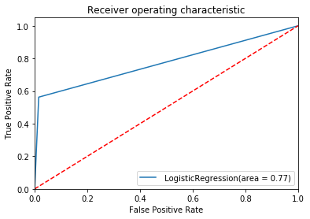

```python
# ROC Curve

lr_roc_auc = roc_auc_score(y_test, lr_test_predict)

fpr, tpr, thresholds = roc_curve(y_test, lr_test_predict)
plt.figure()
plt.plot(fpr, tpr, label=' LogisticRegression(area = %0.2f)' % lr_roc_auc)
plt.plot([0, 1], [0, 1],'r--')
plt.xlim([0.0, 1.0])
plt.ylim([0.0, 1.05])
plt.xlabel('False Positive Rate')
plt.ylabel('True Positive Rate')
plt.title('Receiver operating characteristic')
plt.legend(loc="lower right")
plt.savefig('lr_ROC')
plt.show()
```

```python
#Naive Bayes

from sklearn.naive_bayes import GaussianNB # using Gaussian algorithm from Naive Bayes

# create the model
nb = GaussianNB()

nb.fit(x_train, y_train)

from sklearn import metrics

nb_train_predict = nb.predict(x_train)
nb_test_predict = nb.predict(x_test)


print("Model Accuracy for Training Data: {0:.4f}".format(metrics.accuracy_score(y_train, nb_train_predict)))
print("Model Accuracy for Testing Data: {0:.4f}".format(metrics.accuracy_score(y_test, nb_test_predict)))

cm=metrics.confusion_matrix(y_test, nb_test_predict, labels=[1, 0])
print('\nConfusion Matrix:\n', cm)

# Classification Report
print('\n{}'.format(classification_report(y_test, nb_test_predict)))

# Accuracy Score
auc = accuracy_score(y_test, nb_test_predict)
print('\nAccuracy Score:\n', auc.round(3))
```

```
Model Accuracy for Training Data: 0.8869
Model Accuracy for Testing Data: 0.8860

Confusion Matrix:
 [[  76   52]
 [ 119 1253]]

              precision    recall  f1-score   support

           0       0.96      0.91      0.94      1372
           1       0.39      0.59      0.47       128

    accuracy                           0.89      1500
   macro avg       0.67      0.75      0.70      1500
weighted avg       0.91      0.89      0.90      1500


Accuracy Score:
 0.886
```

From the confusion matrix

1. True positives - 76
2. True Negatives - 1253
3. False Positives(type 1 error) - 119
4. False Negatives(type 2 error) - 52

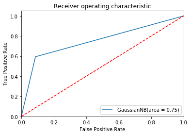

```python
nb_roc_auc = roc_auc_score(y_test, nb_test_predict)

fpr, tpr, thresholds = roc_curve(y_test, nb_test_predict)
plt.figure()
plt.plot(fpr, tpr, label=' GaussianNB(area = %0.2f)' % nb_roc_auc)
plt.plot([0, 1], [0, 1],'r--')
plt.xlim([0.0, 1.0])
plt.ylim([0.0, 1.05])
plt.xlabel('False Positive Rate')
plt.ylabel('True Positive Rate')
plt.title('Receiver operating characteristic')
plt.legend(loc="lower right")
plt.savefig('nb_ROC')
plt.show()
```

```python
#KNN

from sklearn.neighbors import KNeighborsClassifier
from scipy.stats import zscore

NNH = KNeighborsClassifier(n_neighbors= 5 , weights = 'distance' )
NNH.fit(x_train, y_train)

# For every test data point, predict it's label based on 5 nearest neighbours in this model.

NNH_train_predict = NNH.predict(x_train)
NNH_test_predict = NNH.predict(x_test)


print('k-Nearest Neighbor Classifier Scores after Scaling without Hyperparameter Tuning\n\n')
print('k-NN accuracy for train set: {0:.3f}'.format(NNH.score(x_train, y_train)))
print('k-NN accuracy for test set: {0:.3f}'.format(NNH.score(x_test, y_test)))

# Classification Report
print('\n{}'.format(classification_report(y_test, NNH_test_predict)))

# Confusion Matrix
cm = confusion_matrix(y_test, NNH_test_predict)
print('\nConfusion Matrix:\n', cm)

# Accuracy Score
auc = accuracy_score(y_test, NNH_test_predict)
print('\nAccuracy Score:\n', auc.round(3))
```

```
k-Nearest Neighbor Classifier Scores after Scaling without Hyperparameter Tuning


k-NN accuracy for train set: 1.000
k-NN accuracy for test set: 0.924

              precision    recall  f1-score   support

           0       0.95      0.97      0.96      1372
           1       0.58      0.40      0.47       128

    accuracy                           0.92      1500
   macro avg       0.76      0.69      0.72      1500
weighted avg       0.91      0.92      0.92      1500


Confusion Matrix:
 [[1335   37]
 [  77   51]]

Accuracy Score:
 0.924
```

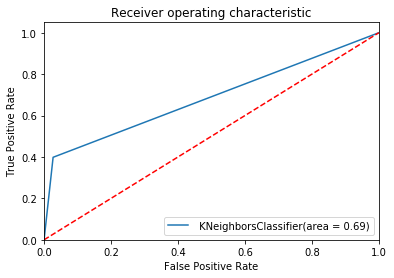

```python
NNH_roc_auc = roc_auc_score(y_test, NNH_test_predict)

fpr, tpr, thresholds = roc_curve(y_test, NNH_test_predict)
plt.figure()
plt.plot(fpr, tpr, label=' KNeighborsClassifier(area = %0.2f)' % NNH_roc_auc)
plt.plot([0, 1], [0, 1],'r--')
plt.xlim([0.0, 1.0])
plt.ylim([0.0, 1.05])
plt.xlabel('False Positive Rate')
plt.ylabel('True Positive Rate')
plt.title('Receiver operating characteristic')
plt.legend(loc="lower right")
plt.savefig('NNH_ROC')
plt.show()
```

## Scaling the variables

#### It can be observed from the data, columns of mortgage, income, ccavg are in thousands of dollars compared to the other variables and hence scaling these values

```python
from scipy.stats import zscore
XScaled  = X.apply(zscore)  # convert all attributes to Z scale
XScaled.describe()
```

|  | Age | Income | Family | CCAvg | Education | Mortgage | Securities Account | CD Account | Online | CreditCard |
| --- | --- | --- | --- | --- | --- | --- | --- | --- | --- | --- |
| count | 5.000000e+03 | 5.000000e+03 | 5.000000e+03 | 5.000000e+03 | 5.000000e+03 | 5.000000e+03 | 5.000000e+03 | 5.000000e+03 | 5.000000e+03 | 5.000000e+03 |
| mean | 2.478018e-17 | 1.939449e-16 | 7.850609e-16 | -2.078338e-17 | -6.315837e-16 | 2.810197e-16 | 5.092149e-16 | 4.426903e-16 | 2.986500e-16 | -3.697931e-16 |
| std | 1.000100e+00 | 1.000100e+00 | 1.000100e+00 | 1.000100e+00 | 1.000100e+00 | 1.000100e+00 | 1.000100e+00 | 1.000100e+00 | 1.000100e+00 | 1.000100e+00 |
| min | -1.948906e+00 | -1.428969e+00 | -1.216855e+00 | -1.108987e+00 | -1.049078e+00 | -5.555239e-01 | -3.414233e-01 | -2.535403e-01 | -1.216618e+00 | -6.453143e-01 |
| 25% | -9.019702e-01 | -7.554825e-01 | -1.216855e+00 | -7.084116e-01 | -1.049078e+00 | -5.555239e-01 | -3.414233e-01 | -2.535403e-01 | -1.216618e+00 | -6.453143e-01 |
| 50% | -2.952359e-02 | -2.123482e-01 | -3.454321e-01 | -2.506106e-01 | 1.417029e-01 | -5.555239e-01 | -3.414233e-01 | -2.535403e-01 | 8.219509e-01 | -6.453143e-01 |
| 75% | 8.429230e-01 | 5.263146e-01 | 5.259909e-01 | 3.216407e-01 | 1.332484e+00 | 4.375576e-01 | -3.414233e-01 | -2.535403e-01 | 8.219509e-01 | 1.549632e+00 |
| max | 1.889859e+00 | 3.263712e+00 | 1.397414e+00 | 4.613525e+00 | 1.332484e+00 | 5.688108e+00 | 2.928915e+00 | 3.944146e+00 | 8.219509e-01 | 1.549632e+00 |

```python
#preparing the new training and testing data set

x_train, x_test, y_train, y_test = train_test_split(XScaled, Y, test_size=0.3, random_state=4)
```

```python
#check the data split

print("{0:0.2f}% data is in training set".format((len(x_train)/len(loan.index)) * 100))
print("{0:0.2f}% data is in test set".format((len(x_test)/len(loan.index)) * 100))
```

```
70.00% data is in training set
30.00% data is in test set
```

#### The next step is to fit various models and check for the best performing one

1. Logistic Regression
2. Naive Bayes
3. KNN

```python
# Logistic Regression
from sklearn import metrics

from sklearn.linear_model import LogisticRegression

# Fit the model on train
lr_scale = LogisticRegression(C=1e5)
lr_scale.fit(x_train, y_train)

from sklearn import metrics

lr_scale_train_predict = lr_scale.predict(x_train)
lr_scale_test_predict = lr_scale.predict(x_test)

print("Model Accuracy for Training Data: {0:.4f}".format(metrics.accuracy_score(y_train, lr_scale_train_predict)))
print("Model Accuracy for Testing Data: {0:.4f}".format(metrics.accuracy_score(y_test, lr_scale_test_predict)))

cm=metrics.confusion_matrix(y_test, lr_scale_test_predict, labels=[1, 0])
print('\nConfusion Matrix:\n', cm)

# Classification Report
print('\n{}'.format(classification_report(y_test, lr_scale_test_predict)))

# Accuracy Score
auc = accuracy_score(y_test, lr_scale_test_predict)
print('\nAccuracy Score:\n', auc.round(3))
```

```
Model Accuracy for Training Data: 0.9523
Model Accuracy for Testing Data: 0.9500

Confusion Matrix:
 [[  86   62]
 [  13 1339]]

              precision    recall  f1-score   support

           0       0.96      0.99      0.97      1352
           1       0.87      0.58      0.70       148

    accuracy                           0.95      1500
   macro avg       0.91      0.79      0.83      1500
weighted avg       0.95      0.95      0.95      1500


Accuracy Score:
 0.95
```

From the confusion matrix

1. True positives - 86
2. True Negatives - 1339
3. False Positives(type 1 error) - 13
4. False Negatives(type 2 error) - 62

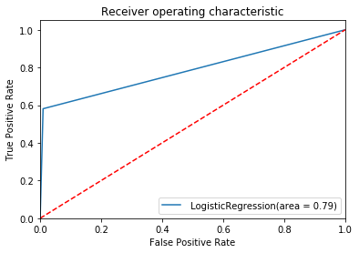

```python
# ROC Curve

lr_scale_roc_auc = roc_auc_score(y_test, lr_scale_test_predict)

fpr, tpr, thresholds = roc_curve(y_test, lr_scale_test_predict)
plt.figure()
plt.plot(fpr, tpr, label=' LogisticRegression(area = %0.2f)' % lr_scale_roc_auc)
plt.plot([0, 1], [0, 1],'r--')
plt.xlim([0.0, 1.0])
plt.ylim([0.0, 1.05])
plt.xlabel('False Positive Rate')
plt.ylabel('True Positive Rate')
plt.title('Receiver operating characteristic')
plt.legend(loc="lower right")
plt.savefig('lr_scale_ROC')
plt.show()
```

```python
#Naive Bayes

from sklearn.naive_bayes import GaussianNB # using Gaussian algorithm from Naive Bayes

# create the model
nb_scale = GaussianNB()

nb_scale.fit(x_train, y_train)

from sklearn import metrics

nb_scale_train_predict = nb_scale.predict(x_train)
nb_scale_test_predict = nb_scale.predict(x_test)


print("Model Accuracy for Training Data: {0:.4f}".format(metrics.accuracy_score(y_train, nb_scale_train_predict)))
print("Model Accuracy for Testing Data: {0:.4f}".format(metrics.accuracy_score(y_test, nb_scale_test_predict)))

cm=metrics.confusion_matrix(y_test, nb_scale_test_predict, labels=[1, 0])
print('\nConfusion Matrix:\n', cm)

# Classification Report
print('\n{}'.format(classification_report(y_test, nb_scale_test_predict)))

# Accuracy Score
auc = accuracy_score(y_test, nb_scale_test_predict)
print('\nAccuracy Score:\n', auc.round(3))
```

```
Model Accuracy for Training Data: 0.8851
Model Accuracy for Testing Data: 0.8933

Confusion Matrix:
 [[  90   58]
 [ 102 1250]]

              precision    recall  f1-score   support

           0       0.96      0.92      0.94      1352
           1       0.47      0.61      0.53       148

    accuracy                           0.89      1500
   macro avg       0.71      0.77      0.73      1500
weighted avg       0.91      0.89      0.90      1500


Accuracy Score:
 0.893
```

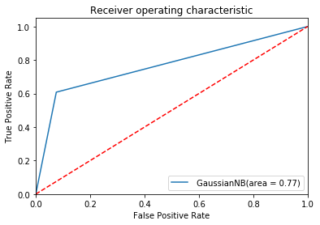

```python
nb_scale_roc_auc = roc_auc_score(y_test, nb_scale_test_predict)

fpr, tpr, thresholds = roc_curve(y_test, nb_scale_test_predict)
plt.figure()
plt.plot(fpr, tpr, label=' GaussianNB(area = %0.2f)' % nb_scale_roc_auc)
plt.plot([0, 1], [0, 1],'r--')
plt.xlim([0.0, 1.0])
plt.ylim([0.0, 1.05])
plt.xlabel('False Positive Rate')
plt.ylabel('True Positive Rate')
plt.title('Receiver operating characteristic')
plt.legend(loc="lower right")
plt.savefig('nb_scale_ROC')
plt.show()
```

```python
#KNN

from sklearn.neighbors import KNeighborsClassifier
from scipy.stats import zscore
```

```python
NNH_scale = KNeighborsClassifier(n_neighbors= 5 , weights = 'distance' )
NNH_scale.fit(x_train, y_train)

# For every test data point, predict it's label based on 5 nearest neighbours in this model

NNH_scale_train_predict = NNH_scale.predict(x_train)
NNH_scale_test_predict = NNH_scale.predict(x_test)


print('k-Nearest Neighbor Classifier Scores after Scaling without Hyperparameter Tuning\n\n')
print('k-NN accuracy for train set: {0:.3f}'.format(NNH_scale.score(x_train, y_train)))
print('k-NN accuracy for test set: {0:.3f}'.format(NNH_scale.score(x_test, y_test)))

#y_true, y_pred = y_test, KNN.predict(x_test)

# Classification Report
print('\n{}'.format(classification_report(y_test,NNH_scale_test_predict )))

# Confusion Matrix
cm = confusion_matrix(y_test, NNH_scale_test_predict)
print('\nConfusion Matrix:\n', cm)

# Accuracy Score
auc = accuracy_score(y_test, NNH_scale_test_predict)
print('\nAccuracy Score:\n', auc.round(3))
```

```
k-Nearest Neighbor Classifier Scores after Scaling without Hyperparameter Tuning


k-NN accuracy for train set: 1.000
k-NN accuracy for test set: 0.963

              precision    recall  f1-score   support

           0       0.96      1.00      0.98      1352
           1       0.98      0.64      0.77       148

    accuracy                           0.96      1500
   macro avg       0.97      0.82      0.88      1500
weighted avg       0.96      0.96      0.96      1500


Confusion Matrix:
 [[1350    2]
 [  54   94]]

Accuracy Score:
 0.963
```

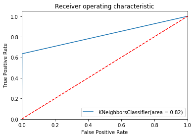

```python
NNH_scale_roc_auc = roc_auc_score(y_test, NNH_scale_test_predict)

fpr, tpr, thresholds = roc_curve(y_test, NNH_scale_test_predict)
plt.figure()
plt.plot(fpr, tpr, label=' KNeighborsClassifier(area = %0.2f)' % NNH_scale_roc_auc)
plt.plot([0, 1], [0, 1],'r--')
plt.xlim([0.0, 1.0])
plt.ylim([0.0, 1.05])
plt.xlabel('False Positive Rate')
plt.ylabel('True Positive Rate')
plt.title('Receiver operating characteristic')
plt.legend(loc="lower right")
plt.savefig('NNH_scale_ROC')
plt.show()
```

### Using cross validation to check if the models improve further

#### Cross validation on the unscaled dataset using ten folds

Note: all the estimators are set to default and the results might vary if the parameters were tuned further

```python
from sklearn.model_selection import cross_val_score
```

```python
lr_cvs = cross_val_score(LogisticRegression(), X, Y,cv=10)
lr_cvs.mean()
```

```
0.9452
```

```python
nb_cvs = cross_val_score(GaussianNB(), X, Y,cv=10)
nb_cvs.mean()
```

```
0.883
```

```python
nnh_cvs = cross_val_score(KNeighborsClassifier(), X, Y,cv=10)
nnh_cvs.mean()
```

```
0.915
```

#### Cross validation the scaled dataset

```python
lr_scale_cvs = cross_val_score(LogisticRegression(), XScaled, Y,cv=10)
lr_scale_cvs.mean()
```

```
0.9506
```

```python
nb_scale_cvs = cross_val_score(GaussianNB(), XScaled, Y,cv=10)
nb_scale_cvs.mean()
```

```
0.883
```

```python
nnh_scale_cvs = cross_val_score(KNeighborsClassifier(), XScaled, Y,cv=10)
nnh_scale_cvs.mean()
```

```
0.9617999999999999
```

## Observations

1. Logistic Reggression and Naive Bayes models have performed closely on the test and train data test and it can be called a fair fit without any cases of overfitting or underfitting except for KNN which had a perfect fit accuracy on train data and was marginally overfitting on the test data
2. For a raw model without scaling and crossvalidation, Logistic Regression performs well followed by KNN and Naive Bayes
3. For a scaled model without crossvalidation, KNN performs better followed by Logistic Regression and Naive Bayes
4. For a raw model with crossvalidation, Logistic Regression performs the best follwed by KNN and Naive Bayes
5. For a scaled model with crossvalidation, KNN performs the best followed by Logistic Regression and Naive Bayes